# Part II - Ford GoBike Data Visualization

## by (Olga Kurguzova)

## Investigation Overview

In this investigation, I wanted to look at the differences in the use of Ford GoBike service for customers and subscribers in terms of: when they use the service, how long their trips lasted and the influence of gender and age

## Dataset Overview

This dataset includes information on 174,278 individual trips made in the "Ford GoBike" bike sharing system covering the greater San Francisco Bay area for February 2019. the data set also includes information about the duration of trips, the availability of a subscription to the system, the start and end date of the trip, the gender and age of the user

## User type destribution

Most of users Ford GoBike service are subscribers (91%)

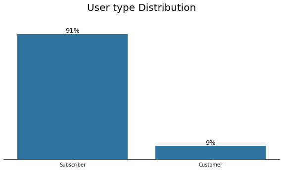

## Gender destribution by user types

The majority of users are men both among subscribers and customers

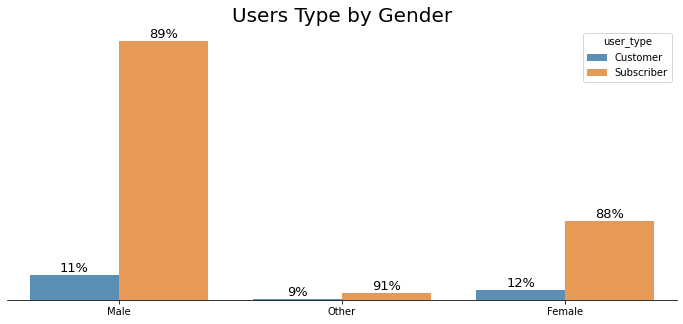

## Time and date of the start of trips by user types

Subscribers mostly use the service during the working week, especially in the evening, while customers use the service throughout the week, especially around noon on weekends. Perhaps subscribers used the service to travel to work or at work, and customers for entertainment. It is worth noting that the trips of customers on average lasted much longer.

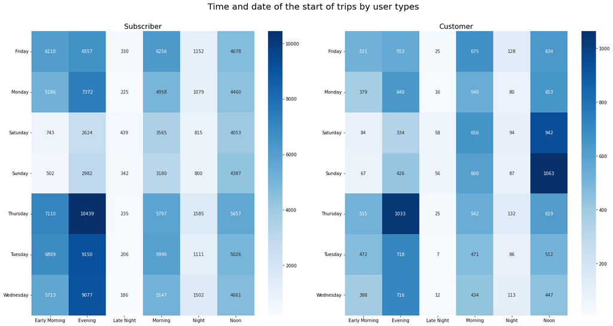

## Average Trip Duration per Subscription

It is worth noting that the trips of customers on average lasted much longer

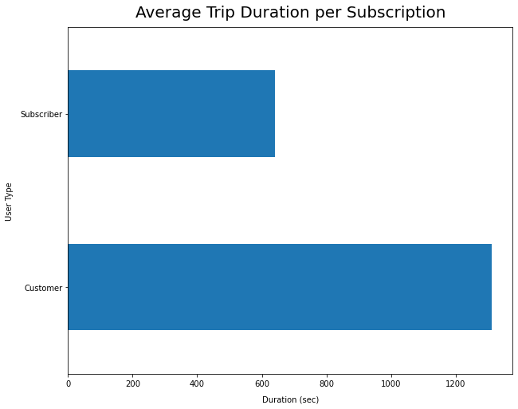